# ch7-Lab

S Zimine

12/5/2017

# Non-Liner Models

```r
require(ISLR)
attach(Wage)
```

## Polynomials

```r
fit <- lm(wage~poly(age,4),data=Wage) #poly degree 4 on 1 predictor
print(summary(fit))
```

```
##
## Call:
## lm(formula = wage ~ poly(age, 4), data = Wage)
##
## Residuals:
##     Min      1Q  Median      3Q     Max
## -98.707 -24.626  -4.993  15.217 203.693
##
## Coefficients:
##                Estimate Std. Error t value Pr(>|t|)
## (Intercept)    111.7036     0.7287 153.283  < 2e-16 ***
## poly(age, 4)1  447.0679    39.9148  11.201  < 2e-16 ***
## poly(age, 4)2 -478.3158    39.9148 -11.983  < 2e-16 ***
## poly(age, 4)3  125.5217    39.9148   3.145  0.00168 **
## poly(age, 4)4  -77.9112    39.9148  -1.952  0.05104 .
## ---
## Signif. codes:  0 '***' 0.001 '**' 0.01 '*' 0.05 '.' 0.1 ' ' 1
##
## Residual standard error: 39.91 on 2995 degrees of freedom
## Multiple R-squared:  0.08626,    Adjusted R-squared:  0.08504
## F-statistic: 70.69 on 4 and 2995 DF,  p-value: < 2.2e-16
```

Based on the summary of fit the Cubic polynomial (degree 3) would be sufficient.

The `poly()` function generates a basis of *orthognoal polynomials*. Lets make a plot of the fitted function, along with the standard errors of the fit.

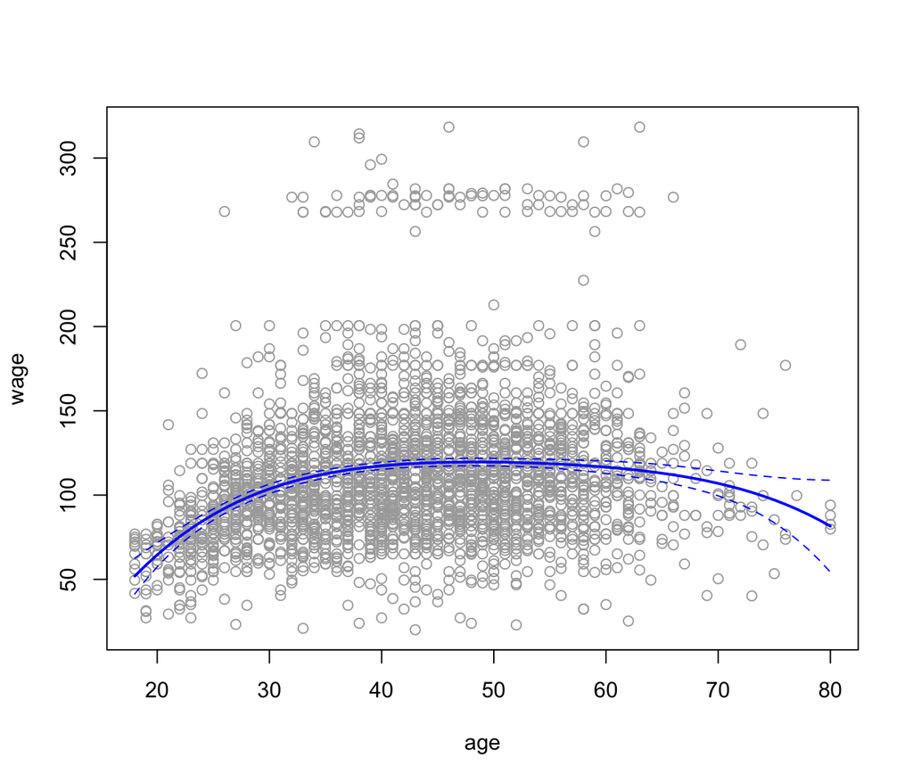

```r
agelims <- range(age)
age.grid <- seq(from=agelims[1], to=agelims[2])
preds <- predict(fit,newdata=list(age=age.grid), se=TRUE  )
se.bands <- cbind(preds$fit+2*preds$se  , preds$fit-2*preds$se )
plot(age,wage,col="darkgrey")
lines(age.grid, preds$fit, lwd=2, col="blue")
matlines(age.grid, se.bands,col="blue", lty=2)
```

There are other more direct ways of doing this plot in R. for example

```r
## with I()
fita <- lm(wage~age+I(age^2)+I(age^3)+I(age^4), data=Wage)
print(summary(fita))
```

```
##
## Call:
## lm(formula = wage ~ age + I(age^2) + I(age^3) + I(age^4), data = Wage)
##
## Residuals:
##     Min      1Q  Median      3Q     Max
## -98.707 -24.626  -4.993  15.217 203.693
##
## Coefficients:
##               Estimate Std. Error t value Pr(>|t|)
## (Intercept) -1.842e+02  6.004e+01  -3.067 0.002180 **
## age          2.125e+01  5.887e+00   3.609 0.000312 ***
## I(age^2)    -5.639e-01  2.061e-01  -2.736 0.006261 **
## I(age^3)     6.811e-03  3.066e-03   2.221 0.026398 *
## I(age^4)    -3.204e-05  1.641e-05  -1.952 0.051039 .
## ---
## Signif. codes:  0 '***' 0.001 '**' 0.01 '*' 0.05 '.' 0.1 ' ' 1
##
## Residual standard error: 39.91 on 2995 degrees of freedom
## Multiple R-squared:  0.08626,    Adjusted R-squared:  0.08504
## F-statistic: 70.69 on 4 and 2995 DF,  p-value: < 2.2e-16
```

Coefficients are not the same but the fitted polynomials ARE.

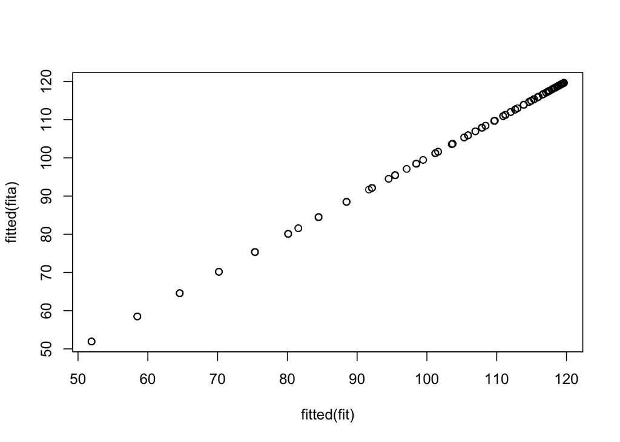

```r
plot(fitted(fit), fitted(fita))
```

How to test a nested sequence of models on the importance of their terms? Use `anova()`

```r
fita <- lm(wage~education,data=Wage)
fitb <- lm(wage~education+age,data=Wage)
fitc <- lm(wage~education+poly(age,2), data=Wage)
fitd <- lm(wage~education+poly(age,3), data=Wage)

anova(fita,fitb,fitc,fitd)
```

```
## Analysis of Variance Table
##
## Model 1: wage ~ education
## Model 2: wage ~ education + age
## Model 3: wage ~ education + poly(age, 2)
## Model 4: wage ~ education + poly(age, 3)
##   Res.Df     RSS Df Sum of Sq        F Pr(>F)
## 1   2995 3995721
## 2   2994 3867992  1    127729 102.7378 <2e-16 ***
## 3   2993 3725395  1    142597 114.6969 <2e-16 ***
## 4   2992 3719809  1      5587   4.4936 0.0341 *
## ---
## Signif. codes:  0 '***' 0.001 '**' 0.01 '*' 0.05 '.' 0.1 ' ' 1
```

### Polynomial logistic

Now we fit a logistic regression model to a binary response variable, constructed from `Wage`. We can observe from a plot a band of high earners (`>250K`)

```r
lgfit <- glm(I(wage>250) ~ poly(age,3), data=Wage, family=binomial)
print(summary(fit))
```

```
##
## Call:
## lm(formula = wage ~ poly(age, 4), data = Wage)
##
## Residuals:
##     Min      1Q  Median      3Q     Max
## -98.707 -24.626  -4.993  15.217 203.693
##
## Coefficients:
##                Estimate Std. Error t value Pr(>|t|)
## (Intercept)    111.7036     0.7287 153.283  < 2e-16 ***
## poly(age, 4)1  447.0679    39.9148  11.201  < 2e-16 ***
## poly(age, 4)2 -478.3158    39.9148 -11.983  < 2e-16 ***
## poly(age, 4)3  125.5217    39.9148   3.145  0.00168 **
## poly(age, 4)4  -77.9112    39.9148  -1.952  0.05104 .
## ---
## Signif. codes:  0 '***' 0.001 '**' 0.01 '*' 0.05 '.' 0.1 ' ' 1
##
## Residual standard error: 39.91 on 2995 degrees of freedom
## Multiple R-squared:  0.08626,    Adjusted R-squared:  0.08504
## F-statistic: 70.69 on 4 and 2995 DF,  p-value: < 2.2e-16
```

```r
preds <- predict(lgfit, list(age=age.grid), se=TRUE)
se.bands <- preds$fit + cbind(fit=0, lower=-2*preds$se, upper=2*preds$se)

print(se.bands[1:5,] )
```

```
##         fit      lower     upper
## 1 -7.664756 -10.759826 -4.569686
## 2 -7.324776 -10.106699 -4.542852
## 3 -7.001732  -9.492821 -4.510643
## 4 -6.695229  -8.917158 -4.473300
## 5 -6.404868  -8.378691 -4.431045
```

We have done a computations on the logit scale, To transfer to probabilistic scale we need to apply the inverse logit mapping

$$p=\frac{e^\eta}{1+e^\eta}$$

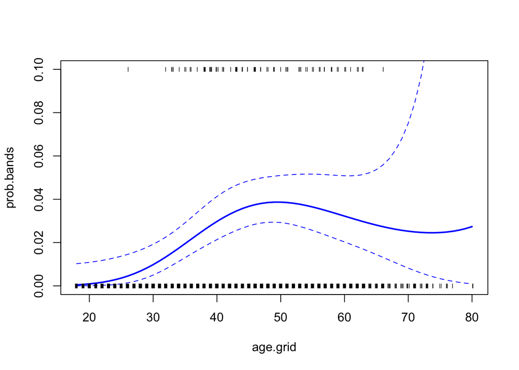

```r
prob.bands <- exp(se.bands) / (1+exp(se.bands))
matplot(age.grid, prob.bands,col="blue", lwd=c(2,1,1), lty=c(1,2,2),
        type="l", ylim=c(0,.1)  )
points(jitter(age), I(wage>250)/10, pch="l", cex=.5)
```

# Splines

Splines are more flexible than polynomials, but the idea is rather similar. Here we will explore cubic splines

```r
require(splines)
```

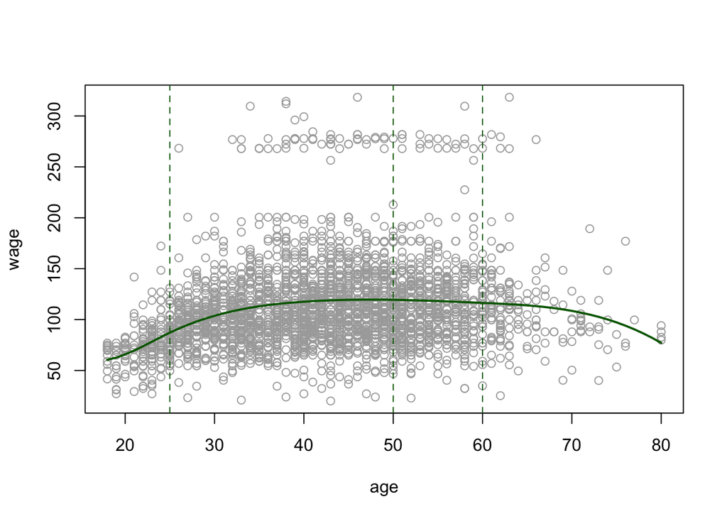

```r
fit<-lm(wage~bs(age,knots=c(25,40,60)), data=Wage )
#print(summary(fit))
plot(age,wage, col="darkgrey")
lines(age.grid, predict(fit, list(age=age.grid)),col="darkgreen",lwd=2 )
abline(v=c(25,50,60), lty=2, col="darkgreen" )
```